# M3 Time Series Decomposition

```python
import pandas as pd
from pandas.plotting import register_matplotlib_converters
import matplotlib.pyplot as plt
import numpy as np
%matplotlib inline
dfCT = pd.read_csv('ConstructionTimeSeriesDatav2.csv')
dfCT.head()
```

|  | Month | Month-Year | Total Construction | Private Construction | Public Construction |
| --- | --- | --- | --- | --- | --- |
| 0 | 1 | Jan-02 | 59516 | 45273 | 14243 |
| 1 | 2 | Feb-02 | 58588 | 44475 | 14113 |
| 2 | 3 | Mar-02 | 63782 | 49396 | 14386 |
| 3 | 4 | Apr-02 | 69504 | 53283 | 16221 |
| 4 | 5 | May-02 | 73384 | 55009 | 18375 |

We begin by taking a look at the data and creating a graph for analyzation. Below is the time series of both the Private and Public Construction data that shows the value from January 2002 to February 2014.  
We can see that the Private Construction has much more value that the Public Construction, although during the Great Recession the Private Construction spending dipped down significantly close to the amount of spending in Public Construction.

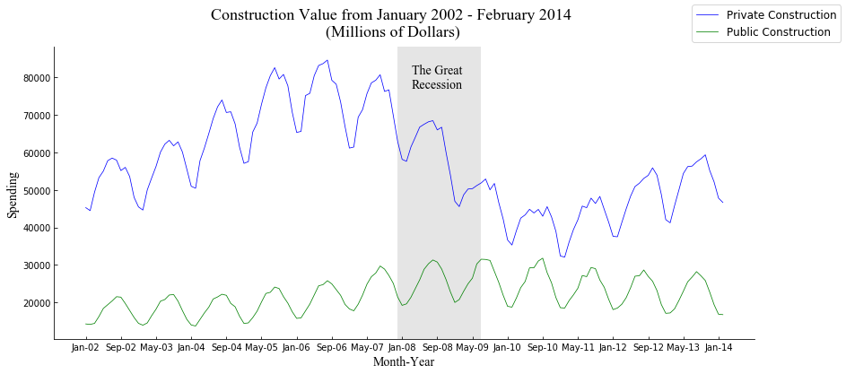

```python
fig,ax = plt.subplots()

x = dfCT['Month-Year']
y1 = dfCT['Private Construction']
y2 = dfCT['Public Construction']

ax.plot(x,y1,color='b',linewidth=.75,label='Private Construction')
ax.plot(x,y2,color='g',linewidth=.75,label='Public Construction')

ax.xaxis.set_tick_params(which = 'both', top = False, bottom = True, labelbottom = True, direction='in')
ax.yaxis.set_tick_params(which = 'both', right = False, left = True, labelleft = True, direction='in')

ax.spines['right'].set_visible(False)
ax.spines['top'].set_visible(False)
ax.set_xlabel('Month-Year',fontsize='14',fontname='Times New Roman')
ax.set_ylabel('Spending',fontsize='14',fontname='Times New Roman')
ax.set_xticks(x[::8])

ax.axvspan(71,90,ymin=0,ymax = 300,facecolor='k',alpha=0.1)
ax.text('Sep-08',80000,'The Great\nRecession',fontsize=14,verticalalignment='center',horizontalalignment='center',fontname='Times New Roman')
fig.legend(fontsize=12)

fig.set_size_inches(14,6)
fig.suptitle("Construction Value from January 2002 - February 2014 \n(Millions of Dollars)",fontsize='18',fontname='Times New Roman')
fig.savefig('constructionplot.jpg',dpi=600)
```

## Decomposition of Private Constructions

We begin with a quick graph of the Private Construction. It appears as if there is seasonality and cyclicality to the time series. This time series also does not have a linear trend, therefore we must use a moving average and the squared error to begin the decomposition of the Private Construction time series.

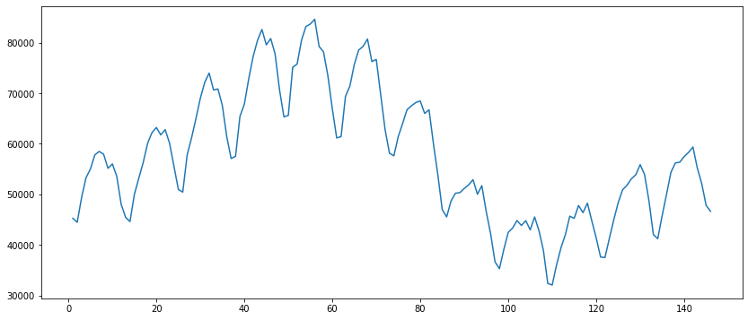

```python
dfPrv = dfCT.loc[:, ('Month', 'Private Construction')]

fig,ax = plt.subplots()
ax.plot(dfPrv['Month'], dfPrv['Private Construction'])
fig.set_size_inches(14,6)
```

```
Average Squared Error per Month:  31701673.583670188
            Month  Private Construction        MovAvg         sqErr
2002-07-31      7                 58494  52878.250000  3.153665e+07
2002-08-31      8                 57953  52892.625000  2.560740e+07
2002-09-30      9                 55157  52923.666667  4.987778e+06
2002-10-31     10                 56023  52945.000000  9.474084e+06
2002-11-30     11                 53552  52994.541667  3.107598e+05
...           ...                   ...           ...           ...
2013-04-30    136                 50022  51844.583333  3.321810e+06
2013-05-31    137                 54369  52041.708333  5.416287e+06
2013-06-30    138                 56228  52235.083333  1.594338e+07
2013-07-31    139                 56354  52616.291667  1.397046e+07
2013-08-31    140                 57481  53082.125000  1.935010e+07

[134 rows x 4 columns]
```

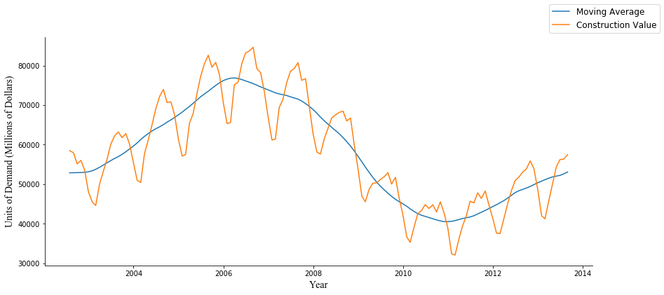

```python
def sqErr(row):
    return (row['Private Construction'] - row['MovAvg'])**2

dfPrv['MovAvg'] = np.NaN
dfPrv['sqErr'] = np.NaN

dfPrv.index = pd.date_range(start='1-31-2002', freq='m', periods = len(dfPrv['Private Construction']))

window = 12
window = window - window % 2

for i in range(int(window/2),dfPrv.shape[0]-int(window/2)):
    dfPrv.loc[dfPrv.index[i],'MovAvg'] = (0.5*dfPrv.iloc[i - int(window/2)]['Private Construction'] + dfPrv.iloc[i - int(window/2)+1:i + int(window/2)]['Private Construction'].sum() + 0.5*dfPrv.iloc[i + int(window/2)]['Private Construction'])/float(window)

dfPrv['sqErr'] = (dfPrv['Private Construction'] - dfPrv['MovAvg'])**2

dfPrv.dropna(how='any',inplace=True)

fig,ax = plt.subplots()
ax.plot(dfPrv['MovAvg'],label='Moving Average')
ax.plot(dfPrv['Private Construction'],label='Construction Value')
ax.set_xlabel('Year',fontsize='14',fontname='Times New Roman')
ax.set_ylabel('Units of Demand (Millions of Dollars)',fontsize='14',fontname='Times New Roman')
ax.spines['right'].set_visible(False)
ax.spines['top'].set_visible(False)
fig.legend(fontsize=12)
fig.set_size_inches(14,6)

print('Average Squared Error per Month: ',sum(dfPrv['sqErr'])/len(dfPrv))
print(dfPrv)
```

Then the Residuals must be computed in order to find the trend.

```python
dfPrv['R1'] = dfPrv['Private Construction'] - dfPrv['MovAvg']
dfPrv['R1Error'] = abs((dfPrv['Private Construction'] - dfPrv['R1'])/dfPrv['Private Construction'])
dfPrv.style.format({
    'MovAvg': '{:.1f}'.format,
    'sqErr': '{:,.1f}'.format,
    'R1': '{:,.1f}'.format,
    'R1Error': '{:,.3f}'.format
    })
```

|  | Month | Private Construction | MovAvg | sqErr | R1 | R1Error |
| --- | --- | --- | --- | --- | --- | --- |
| 2002-07-31 00:00:00 | 7 | 58494 | 52878.2 | 31,536,648.1 | 5,615.8 | 0.904 |
| 2002-08-31 00:00:00 | 8 | 57953 | 52892.6 | 25,607,395.1 | 5,060.4 | 0.913 |
| 2002-09-30 00:00:00 | 9 | 55157 | 52923.7 | 4,987,777.8 | 2,233.3 | 0.960 |
| 2002-10-31 00:00:00 | 10 | 56023 | 52945.0 | 9,474,084.0 | 3,078.0 | 0.945 |
| 2002-11-30 00:00:00 | 11 | 53552 | 52994.5 | 310,759.8 | 557.5 | 0.990 |
| 2002-12-31 00:00:00 | 12 | 48023 | 53142.5 | 26,209,706.9 | -5,119.5 | 1.107 |
| 2003-01-31 00:00:00 | 13 | 45473 | 53392.4 | 62,717,160.3 | -7,919.4 | 1.174 |
| 2003-02-28 00:00:00 | 14 | 44620 | 53767.5 | 83,677,518.5 | -9,147.5 | 1.205 |
| 2003-03-31 00:00:00 | 15 | 49996 | 54263.0 | 18,207,289.0 | -4,267.0 | 1.085 |
| 2003-04-30 00:00:00 | 16 | 53195 | 54821.3 | 2,644,960.1 | -1,626.3 | 1.031 |
| 2003-05-31 00:00:00 | 17 | 56286 | 55377.7 | 824,993.8 | 908.3 | 0.984 |
| 2003-06-30 00:00:00 | 18 | 60076 | 55966.2 | 16,890,387.5 | 4,109.8 | 0.932 |
| 2003-07-31 00:00:00 | 19 | 62216 | 56510.5 | 32,552,730.2 | 5,705.5 | 0.908 |
| 2003-08-31 00:00:00 | 20 | 63234 | 56982.6 | 39,079,689.4 | 6,251.4 | 0.901 |
| 2003-09-30 00:00:00 | 21 | 61767 | 57550.5 | 17,778,872.2 | 4,216.5 | 0.932 |
| 2003-10-31 00:00:00 | 22 | 62813 | 58208.1 | 21,205,257.5 | 4,604.9 | 0.927 |
| 2003-11-30 00:00:00 | 23 | 60115 | 58904.9 | 1,464,402.5 | 1,210.1 | 0.980 |
| 2003-12-31 00:00:00 | 24 | 55584 | 59642.5 | 16,471,760.5 | -4,058.5 | 1.073 |
| 2004-01-31 00:00:00 | 25 | 50975 | 60430.8 | 89,411,208.1 | -9,455.8 | 1.185 |
| 2004-02-29 00:00:00 | 26 | 50449 | 61294.1 | 117,616,736.3 | -10,845.1 | 1.215 |
| 2004-03-31 00:00:00 | 27 | 57796 | 62113.4 | 18,639,726.9 | -4,317.4 | 1.075 |
| 2004-04-30 00:00:00 | 28 | 61177 | 62819.1 | 2,696,574.5 | -1,642.1 | 1.027 |
| 2004-05-31 00:00:00 | 29 | 65027 | 63465.5 | 2,438,282.2 | 1,561.5 | 0.976 |
| 2004-06-30 00:00:00 | 30 | 69039 | 64020.7 | 25,183,669.4 | 5,018.3 | 0.927 |
| 2004-07-31 00:00:00 | 31 | 72170 | 64519.5 | 58,529,512.7 | 7,650.5 | 0.894 |
| 2004-08-31 00:00:00 | 32 | 74001 | 65069.6 | 79,770,203.7 | 8,931.4 | 0.879 |
| 2004-09-30 00:00:00 | 33 | 70662 | 65682.5 | 24,795,005.3 | 4,979.5 | 0.930 |
| 2004-10-31 00:00:00 | 34 | 70856 | 66277.6 | 20,961,899.2 | 4,578.4 | 0.935 |
| 2004-11-30 00:00:00 | 35 | 67585 | 66881.2 | 495,322.7 | 703.8 | 0.990 |
| 2004-12-31 00:00:00 | 36 | 61438 | 67550.1 | 37,358,072.0 | -6,112.1 | 1.099 |

[output cut: 104 more lines]

```
Average Residual:  30.595149253731616
```

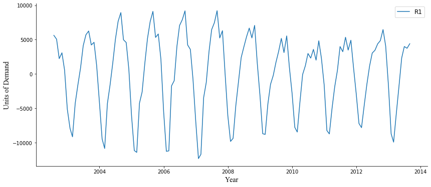

```python
fig,ax = plt.subplots()
ax.plot(dfPrv['R1'], label='R1')
ax.set_xlabel('Year',fontsize='14',fontname='Times New Roman')
ax.set_ylabel('Units of Demand',fontsize='14',fontname='Times New Roman')
ax.spines['right'].set_visible(False)
ax.spines['top'].set_visible(False)
ax.legend(fontsize=12)
fig.set_size_inches(14,6)

print('Average Residual: ', sum(dfPrv['R1'])/len(dfPrv))
```

```python
maxCorr = 0.0
period = np.NaN
for i in range(1,13):
    corr = dfPrv['R1'].autocorr(lag=i)
    print('Correlation, lag ',i,'   ',corr)
    if corr > maxCorr:
        maxCorr = corr
        period = i
print('period = ',period,'     Maximum Correlation = ',maxCorr)
```

```
Correlation, lag  1     0.8012201439941184
Correlation, lag  2     0.4046160901273205
Correlation, lag  3     -0.06681918914657627
Correlation, lag  4     -0.46817065394656976
Correlation, lag  5     -0.7334595961596322
Correlation, lag  6     -0.8453947574465044
Correlation, lag  7     -0.7277714550926001
Correlation, lag  8     -0.45905643208796504
Correlation, lag  9     -0.06590030685316585
Correlation, lag  10     0.38876557877044954
Correlation, lag  11     0.7742521355064202
Correlation, lag  12     0.9718794492320808
period =  12      Maximum Correlation =  0.9718794492320808
```

After computing the lags, lag 12 is the lag that has the most significance. The graph below shows the average of the cycles and it closely follows the cycles.

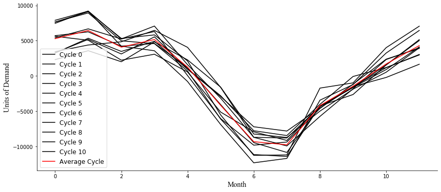

```python
period = 12
cycleLen = period
numCycles = int(len(dfPrv)/cycleLen + 0.5)
cycles = [dfPrv.iloc[range(i*period,min((i+1)*period,len(dfCT)))]['R1'] for i in range(numCycles)]
ptsInCycles = [dfPrv.iloc[range(i,len(dfPrv['R1']),period)]['R1'].tolist() for i in range(period)]
avg = [sum(pts)/len(pts) for pts in ptsInCycles]

fig,ax = plt.subplots()
for i in range(len(cycles)):
    ax.plot(cycles[i].values,label='Cycle '+str(i),c='k')
ax.plot(avg,label='Average Cycle',c='r')
ax.set_xlabel('Month',fontsize='14',fontname='Times New Roman')
ax.set_ylabel('Units of Demand',fontsize='14',fontname='Times New Roman')
ax.spines['right'].set_visible(False)
ax.spines['top'].set_visible(False)
ax.legend(fontsize=12)
fig.set_size_inches(14,6)
```

The remainder after the trend follows the cyclic pattern closely.

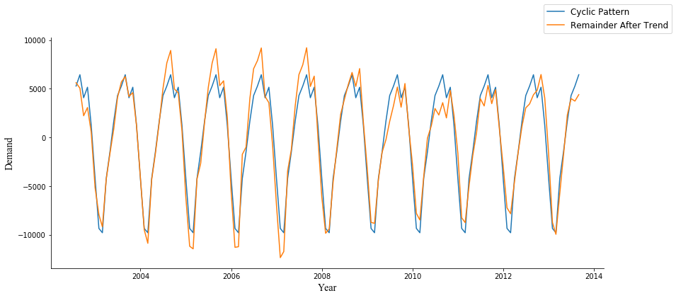

```python
cycleLen = period   # see prior cell for computation of cyclicality period
numCycles = int(len(dfPrv)/cycleLen + 0.5)
dfPrv['C'] = np.NaN
for i in range(len(dfPrv)):
    dfPrv.loc[dfPrv.index[i], 'C'] = avg[i % cycleLen]

fig,ax = plt.subplots()
ax.plot(dfPrv['C'],label='Cyclic Pattern')
ax.plot(dfPrv['R1'],label='Remainder After Trend')
ax.set_xlabel('Year',fontsize='14',fontname='Times New Roman')
ax.set_ylabel('Demand',fontsize='14',fontname='Times New Roman')
ax.spines['right'].set_visible(False)
ax.spines['top'].set_visible(False)
fig.legend(fontsize=12)
fig.set_size_inches(14,6)
```

```
Average Error:  0.020585783569537188
            Month  Private Construction        MovAvg         sqErr  \
2002-07-31      7                 58494  52878.250000  3.153665e+07
2002-08-31      8                 57953  52892.625000  2.560740e+07
2002-09-30      9                 55157  52923.666667  4.987778e+06
2002-10-31     10                 56023  52945.000000  9.474084e+06
2002-11-30     11                 53552  52994.541667  3.107598e+05
...           ...                   ...           ...           ...
2013-04-30    136                 50022  51844.583333  3.321810e+06
2013-05-31    137                 54369  52041.708333  5.416287e+06
2013-06-30    138                 56228  52235.083333  1.594338e+07
2013-07-31    139                 56354  52616.291667  1.397046e+07
2013-08-31    140                 57481  53082.125000  1.935010e+07

                     R1   R1Error            C           R2  R2ErrorX  \
2002-07-31  5615.750000  0.903994  5281.409722   334.340278  0.005716
2002-08-31  5060.375000  0.912681  6441.833333 -1381.458333  0.023838
2002-09-30  2233.333333  0.959510  4081.571970 -1848.238636  0.033509
2002-10-31  3078.000000  0.945058  5159.443182 -2081.443182  0.037153
2002-11-30   557.458333  0.989590  1250.583333  -693.125000  0.012943
...                 ...       ...          ...          ...       ...
2013-04-30 -1822.583333  1.036436 -1459.571970  -363.011364  0.007257
2013-05-31  2327.291667  0.957195  1697.541667   629.750000  0.011583
2013-06-30  3992.916667  0.928987  4304.223485  -311.306818  0.005537
2013-07-31  3737.708333  0.933674  5281.409722 -1543.701389  0.027393
2013-08-31  4398.875000  0.923473  6441.833333 -2042.958333  0.035541

                     R2X
2002-07-31  58159.659722
2002-08-31  59334.458333
2002-09-30  57005.238636
2002-10-31  58104.443182
2002-11-30  54245.125000
...                  ...
2013-04-30  50385.011364
2013-05-31  53739.250000
2013-06-30  56539.306818
2013-07-31  57897.701389
2013-08-31  59523.958333

[134 rows x 10 columns]
```

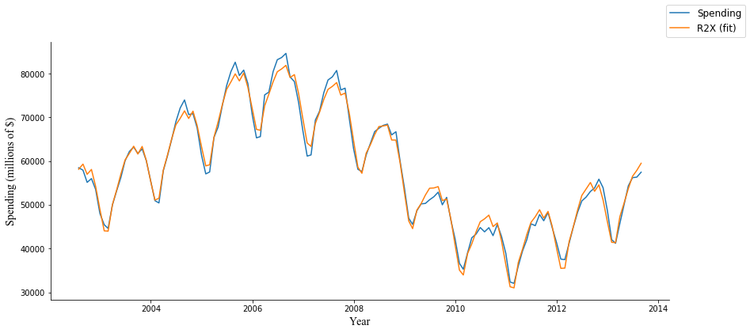

```python
dfPrv['R2'] = dfPrv['R1'] - dfPrv['C']
dfPrv['R2ErrorX'] = abs(dfPrv['R2']/dfPrv['Private Construction'])
dfPrv['R2X'] = dfPrv['MovAvg'] + dfPrv['C']

print('Average Error: ', sum(dfPrv['R2ErrorX'])/len(dfPrv))
print(dfPrv)
fig,ax = plt.subplots()
ax.plot(dfPrv['Private Construction'],label='Spending')
ax.plot(dfPrv['R2X'], label = 'R2X (fit)')
ax.set_xlabel('Year',fontsize='14',fontname='Times New Roman')
ax.set_ylabel('Spending (millions of $)',fontsize='14',fontname='Times New Roman')
ax.spines['right'].set_visible(False)
ax.spines['top'].set_visible(False)
fig.legend(loc=1, fontsize=12)
fig.set_size_inches(14,6)
```

After finding the R2X, the model closely follows that of the Private Construction Spending. This ensures it is a good fit.

```
Correlation, lag  1     0.6750893529818791
Correlation, lag  2     0.34510105026697396
Correlation, lag  3     -0.04646932554791686
Correlation, lag  4     -0.31441699093452624
Correlation, lag  5     -0.5264754747503062
Correlation, lag  6     -0.5704888079897079
Correlation, lag  7     -0.46742408108255296
Correlation, lag  8     -0.25406846549220946
Correlation, lag  9     -0.05957853056153247
Correlation, lag  10     0.20420845508027602
Correlation, lag  11     0.3982803613194881
Correlation, lag  12     0.5641711274992344
Correlation, lag  13     0.3885919868474464
Correlation, lag  14     0.24867903514059794
Correlation, lag  15     -0.01280108233581247
Correlation, lag  16     -0.17244389682993275
Correlation, lag  17     -0.3198723342230055
Correlation, lag  18     -0.3397289162773922
Correlation, lag  19     -0.24647882498648627
Correlation, lag  20     -0.10355796515376617
Correlation, lag  21     0.00925439780050097
Correlation, lag  22     0.13661370877248732
Correlation, lag  23     0.2361344892661341
Correlation, lag  24     0.25446303473273785
period =  1      Maximum Correlation =  0.6750893529818791
```

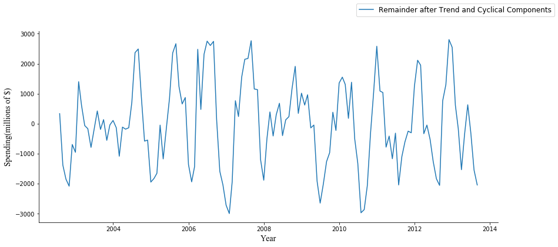

```python
fig,ax = plt.subplots()
ax.plot(dfPrv['R2'],label='Remainder after Trend and Cyclical Components')
ax.set_xlabel('Year',fontsize='14',fontname='Times New Roman')
ax.set_ylabel('Spending(millions of $)',fontsize='14',fontname='Times New Roman')
ax.spines['right'].set_visible(False)
ax.spines['top'].set_visible(False)
fig.legend(fontsize=12)
fig.set_size_inches(14,6)
maxCorr = 0.0
period = np.NaN
for i in range(1,25):
    corr = dfPrv['R2'].autocorr(lag=i)
    print('Correlation, lag ',i,'   ',corr)
    if corr > maxCorr:
        maxCorr = corr
        period = i
print('period = ',period,'     Maximum Correlation = ',maxCorr)
```

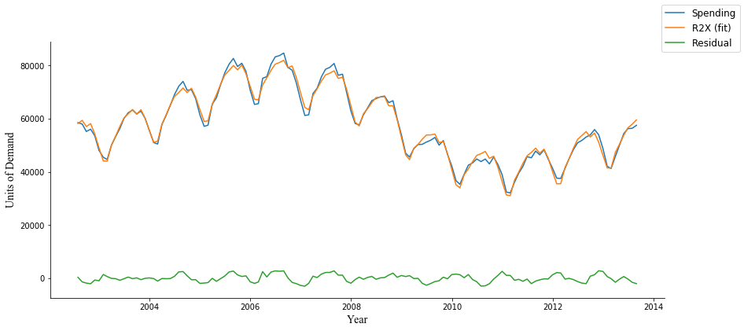

```python
fig,ax = plt.subplots()
ax.plot(dfPrv['Private Construction'],label='Spending')
ax.plot(dfPrv['R2X'],label='R2X (fit)')
ax.plot(dfPrv['R2'],label='Residual')
ax.set_xlabel('Year',fontsize='14',fontname='Times New Roman')
ax.set_ylabel('Units of Demand',fontsize='14',fontname='Times New Roman')
ax.spines['right'].set_visible(False)
ax.spines['top'].set_visible(False)
fig.legend(fontsize=12)

fig.set_size_inches(14,6)
```

The residuals are now very minimal, showing that the model is a good fit for this data.

```python
for a in [0.1 * i for i in range(1,20)]:
    dfPrv['aC'] = a*dfPrv['C']
    dfPrv['R3'] = dfPrv['R1'] - dfPrv['aC']
    dfPrv['sqErr'] = dfPrv['R3']**2
    print('Squared Error for a =','{:.1f}'.format(a),':',sum(dfPrv['sqErr']))
```

```
Squared Error for a = 0.1 : 3493035810.6966357
Squared Error for a = 0.2 : 2817519829.5514827
Squared Error for a = 0.3 : 2221476316.776349
Squared Error for a = 0.4 : 1704905272.3712325
Squared Error for a = 0.5 : 1267806696.3361347
Squared Error for a = 0.6 : 910180588.6710539
Squared Error for a = 0.7 : 632026949.3759911
Squared Error for a = 0.8 : 433345778.4509467
Squared Error for a = 0.9 : 314137075.8959202
Squared Error for a = 1.0 : 274400841.7109112
Squared Error for a = 1.1 : 314137075.8959201
Squared Error for a = 1.2 : 433345778.4509473
Squared Error for a = 1.3 : 632026949.375992
Squared Error for a = 1.4 : 910180588.6710545
Squared Error for a = 1.5 : 1267806696.3361342
Squared Error for a = 1.6 : 1704905272.371233
Squared Error for a = 1.7 : 2221476316.7763495
Squared Error for a = 1.8 : 2817519829.551484
Squared Error for a = 1.9 : 3493035810.696636
```

## Decomposition of Public Construction

```python
dfPub = dfCT.loc[:, ('Month', 'Public Construction')]
dfPub
```

|  | Month | Public Construction |
| --- | --- | --- |
| 0 | 1 | 14243 |
| 1 | 2 | 14113 |
| 2 | 3 | 14386 |
| 3 | 4 | 16221 |
| 4 | 5 | 18375 |
| ... | ... | ... |
| 141 | 142 | 25823 |
| 142 | 143 | 22741 |
| 143 | 144 | 19369 |
| 144 | 145 | 16834 |
| 145 | 146 | 16721 |

146 rows × 2 columns

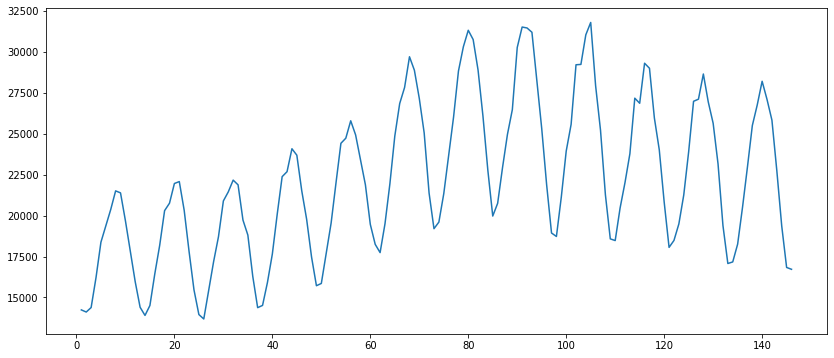

```python
fig,ax = plt.subplots()
ax.plot(dfPub['Month'], dfPub['Public Construction'])
fig.set_size_inches(14,6)
```

```
Average Squared Error per Month:  13046470.551357789
            Month  Public Construction        MovAvg         sqErr
2002-07-31      7                20369  17793.208333  6.634703e+06
2002-08-31      8                21507  17791.291667  1.380649e+07
2002-09-30      9                21385  17787.833333  1.293961e+07
2002-10-31     10                19687  17802.291667  3.552126e+06
2002-11-30     11                17810  17803.750000  3.906250e+01
...           ...                  ...           ...           ...
2013-04-30    136                20513  22647.708333  4.556980e+06
2013-05-31    137                22959  22638.708333  1.025868e+05
2013-06-30    138                25495  22620.625000  8.262032e+06
2013-07-31    139                26750  22609.500000  1.714374e+07
2013-08-31    140                28196  22580.750000  3.153103e+07

[134 rows x 4 columns]
```

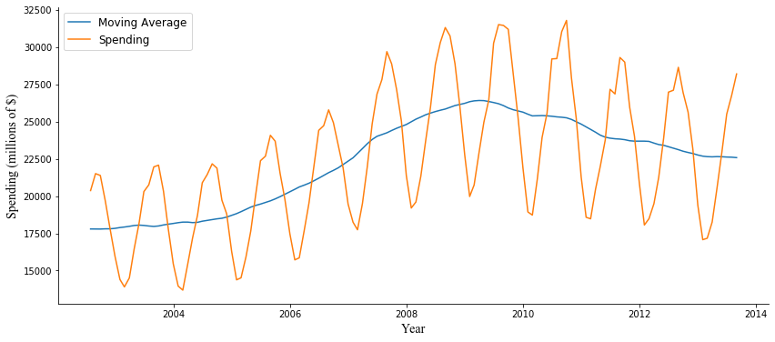

```python
def sqErr(row):
    return (row['Public Construction'] - row['MovAvg'])**2

dfPub['MovAvg'] = np.NaN
dfPub['sqErr'] = np.NaN

dfPub.index = pd.date_range(start='1-31-2002',freq='m', periods = len(dfPub['Public Construction']))

window = 12
window = window - window % 2

for i in range(int(window/2),dfPub.shape[0]-int(window/2)):
    dfPub.loc[dfPub.index[i],'MovAvg'] = (0.5*dfPub.iloc[i - int(window/2)]['Public Construction'] +
                                          dfPub.iloc[i - int(window/2)+1:i + int(window/2)]['Public Construction'].sum() +
                                          0.5*dfPub.iloc[i + int(window/2)]['Public Construction'])/float(window)

dfPub['sqErr'] = (dfPub['Public Construction'] - dfPub['MovAvg'])**2

dfPub.dropna(how='any',inplace=True)

fig,ax = plt.subplots()
ax.plot(dfPub['MovAvg'],label='Moving Average')
ax.plot(dfPub['Public Construction'],label='Spending')
ax.set_xlabel('Year',fontsize='14',fontname='Times New Roman')
ax.set_ylabel('Spending (millions of $)',fontsize='14',fontname='Times New Roman')
ax.spines['right'].set_visible(False)
ax.spines['top'].set_visible(False)
ax.legend(loc=2, fontsize=12)
fig.set_size_inches(14,6)

print('Average Squared Error per Month: ',sum(dfPub['sqErr'])/len(dfPub))
print(dfPub)
```

```python
dfPub['R1'] = dfPub['Public Construction'] - dfPub['MovAvg']
dfPub['R1Error'] = abs((dfPub['Public Construction'] - dfPub['R1'])/dfPub['Public Construction'])
dfPub.style.format({
    'MovAvg': '{:.1f}'.format,
    'sqErr': '{:,.1f}'.format,
    'R1': '{:,.1f}'.format,
    'R1Error': '{:,.3f}'.format
    })
```

|  | Month | Public Construction | MovAvg | sqErr | R1 | R1Error |
| --- | --- | --- | --- | --- | --- | --- |
| 2002-07-31 00:00:00 | 7 | 20369 | 17793.2 | 6,634,702.7 | 2,575.8 | 0.874 |
| 2002-08-31 00:00:00 | 8 | 21507 | 17791.3 | 13,806,488.4 | 3,715.7 | 0.827 |
| 2002-09-30 00:00:00 | 9 | 21385 | 17787.8 | 12,939,608.0 | 3,597.2 | 0.832 |
| 2002-10-31 00:00:00 | 10 | 19687 | 17802.3 | 3,552,125.5 | 1,884.7 | 0.904 |
| 2002-11-30 00:00:00 | 11 | 17810 | 17803.8 | 39.1 | 6.2 | 1.000 |
| 2002-12-31 00:00:00 | 12 | 15961 | 17834.2 | 3,509,065.6 | -1,873.2 | 1.117 |
| 2003-01-31 00:00:00 | 13 | 14404 | 17888.7 | 12,142,901.8 | -3,484.7 | 1.242 |
| 2003-02-28 00:00:00 | 14 | 13906 | 17923.5 | 16,140,306.2 | -4,017.5 | 1.289 |
| 2003-03-31 00:00:00 | 15 | 14510 | 17971.0 | 11,978,521.0 | -3,461.0 | 1.239 |
| 2003-04-30 00:00:00 | 16 | 16444 | 18026.2 | 2,503,251.4 | -1,582.2 | 1.096 |
| 2003-05-31 00:00:00 | 17 | 18187 | 18052.2 | 18,168.8 | 134.8 | 0.993 |
| 2003-06-30 00:00:00 | 18 | 20301 | 18031.2 | 5,151,954.2 | 2,269.8 | 0.888 |
| 2003-07-31 00:00:00 | 19 | 20755 | 17992.0 | 7,633,938.8 | 2,763.0 | 0.867 |
| 2003-08-31 00:00:00 | 20 | 21957 | 17964.5 | 15,940,389.0 | 3,992.5 | 0.818 |
| 2003-09-30 00:00:00 | 21 | 22075 | 17994.3 | 16,652,180.5 | 4,080.7 | 0.815 |
| 2003-10-31 00:00:00 | 22 | 20321 | 18063.7 | 5,095,365.7 | 2,257.3 | 0.889 |
| 2003-11-30 00:00:00 | 23 | 17801 | 18116.0 | 99,225.0 | -315.0 | 1.018 |
| 2003-12-31 00:00:00 | 24 | 15466 | 18162.4 | 7,270,662.8 | -2,696.4 | 1.174 |
| 2004-01-31 00:00:00 | 25 | 13959 | 18215.8 | 18,120,275.3 | -4,256.8 | 1.305 |
| 2004-02-29 00:00:00 | 26 | 13689 | 18253.1 | 20,831,237.0 | -4,564.1 | 1.333 |
| 2004-03-31 00:00:00 | 27 | 15443 | 18253.5 | 7,898,676.0 | -2,810.5 | 1.182 |
| 2004-04-30 00:00:00 | 28 | 17177 | 18220.4 | 1,088,631.4 | -1,043.4 | 1.061 |
| 2004-05-31 00:00:00 | 29 | 18709 | 18237.6 | 222,233.7 | 471.4 | 0.975 |
| 2004-06-30 00:00:00 | 30 | 20893 | 18314.1 | 6,650,596.3 | 2,578.9 | 0.877 |
| 2004-07-31 00:00:00 | 31 | 21444 | 18366.2 | 9,472,801.5 | 3,077.8 | 0.856 |
| 2004-08-31 00:00:00 | 32 | 22164 | 18418.2 | 14,030,643.1 | 3,745.8 | 0.831 |
| 2004-09-30 00:00:00 | 33 | 21876 | 18472.6 | 11,582,961.4 | 3,403.4 | 0.844 |
| 2004-10-31 00:00:00 | 34 | 19726 | 18512.5 | 1,472,683.4 | 1,213.5 | 0.938 |
| 2004-11-30 00:00:00 | 35 | 18809 | 18590.2 | 47,851.6 | 218.8 | 0.988 |
| 2004-12-31 00:00:00 | 36 | 16295 | 18709.8 | 5,831,420.0 | -2,414.8 | 1.148 |

[output cut: 104 more lines]

```
Average Residual:  57.485074626865725
```

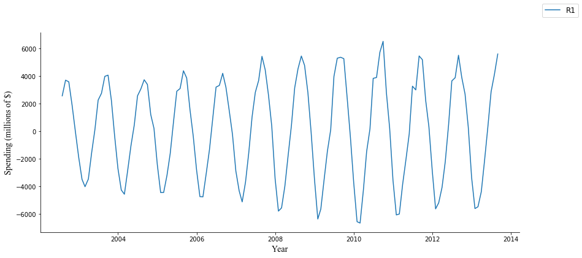

```python
fig,ax = plt.subplots()
ax.plot(dfPub['R1'], label='R1')
ax.set_xlabel('Year',fontsize='14',fontname='Times New Roman')
ax.set_ylabel('Spending (millions of $)',fontsize='14',fontname='Times New Roman')
ax.spines['right'].set_visible(False)
ax.spines['top'].set_visible(False)
fig.legend(fontsize=12)
fig.set_size_inches(14,6)

print('Average Residual: ', sum(dfPub['R1'])/len(dfPub))
```

```python
maxCorr = 0.0
period = np.NaN
for i in range(1,13):
    corr = dfPub['R1'].autocorr(lag=i)
    print('Correlation, lag ',i,'   ',corr)
    if corr > maxCorr:
        maxCorr = corr
        period = i
print('period = ',period,'     Maximum Correlation = ',maxCorr)
```

```
Correlation, lag  1     0.8486260794687956
Correlation, lag  2     0.4813829189118816
Correlation, lag  3     -0.012518854677954341
Correlation, lag  4     -0.5037936790405376
Correlation, lag  5     -0.8444517003136985
Correlation, lag  6     -0.9648820663268396
Correlation, lag  7     -0.8433331333098901
Correlation, lag  8     -0.49319137831949866
Correlation, lag  9     0.003706338528959615
Correlation, lag  10     0.4871379355718062
Correlation, lag  11     0.8469321834384937
Correlation, lag  12     0.9888511486124667
period =  12      Maximum Correlation =  0.9888511486124667
```

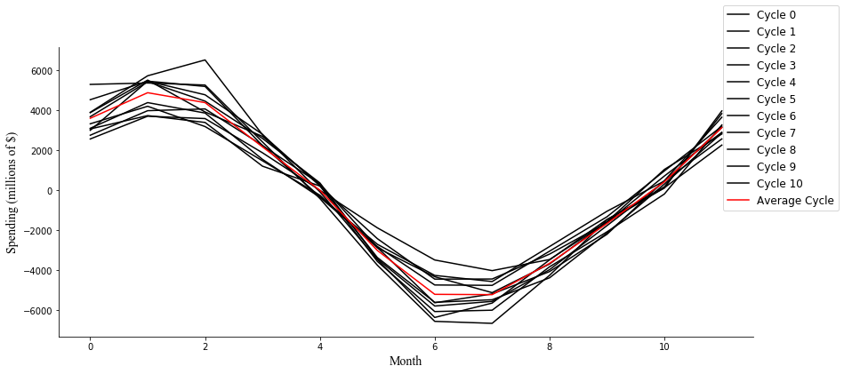

```python
period = 12
cycleLen = period
numCycles = int(len(dfPub)/cycleLen + 0.5)
cycles = [dfPub.iloc[range(i*period,min((i+1)*period,len(dfPub)))]['R1'] for i in range(numCycles)]
ptsInCycles = [dfPub.iloc[range(i,len(dfPub['R1']),period)]['R1'].tolist() for i in range(period)]
avg = [sum(pts)/len(pts) for pts in ptsInCycles]

fig,ax = plt.subplots()
for i in range(len(cycles)):
    ax.plot(cycles[i].values,label='Cycle '+str(i),c='k')
ax.plot(avg,label='Average Cycle',c='r')
ax.set_xlabel('Month',fontsize='14',fontname='Times New Roman')
ax.set_ylabel('Spending (millions of $)',fontsize='14',fontname='Times New Roman')
ax.spines['right'].set_visible(False)
ax.spines['top'].set_visible(False)
fig.legend(fontsize=12)
fig.set_size_inches(14,6)
```

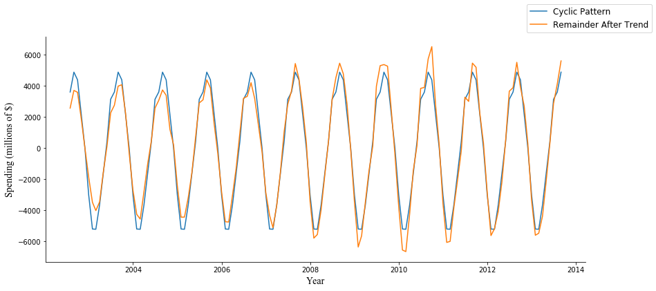

```python
cycleLen = period   # see prior cell for computation of cyclicality period
numCycles = int(len(dfPub)/cycleLen + 0.5)
dfPub['C'] = np.NaN
for i in range(len(dfPub)):
    dfPub.loc[dfPub.index[i], 'C'] = avg[i % cycleLen]

fig,ax = plt.subplots()
ax.plot(dfPub['C'],label='Cyclic Pattern')
ax.plot(dfPub['R1'],label='Remainder After Trend')
ax.set_xlabel('Year',fontsize='14',fontname='Times New Roman')
ax.set_ylabel('Spending (millions of $)',fontsize='14',fontname='Times New Roman')
ax.spines['right'].set_visible(False)
ax.spines['top'].set_visible(False)
fig.legend(fontsize=12)
fig.set_size_inches(14,6)
```

```
Average Error:  0.02442412892884389
            Month  Public Construction        MovAvg           R1   R1Error  \
2002-07-31      7                20369  17793.208333  2575.791667  0.873544
2002-08-31      8                21507  17791.291667  3715.708333  0.827233
2002-09-30      9                21385  17787.833333  3597.166667  0.831790
2002-10-31     10                19687  17802.291667  1884.708333  0.904266
2002-11-30     11                17810  17803.750000     6.250000  0.999649
...           ...                  ...           ...          ...       ...
2013-04-30    136                20513  22647.708333 -2134.708333  1.104066
2013-05-31    137                22959  22638.708333   320.291667  0.986049
2013-06-30    138                25495  22620.625000  2874.375000  0.887257
2013-07-31    139                26750  22609.500000  4140.500000  0.845215
2013-08-31    140                28196  22580.750000  5615.250000  0.800849

                      C           R2  R2ErrorX           R2X
2002-07-31  3613.121528 -1037.329861  0.050927  21406.329861
2002-08-31  4892.736111 -1177.027778  0.054728  22684.027778
2002-09-30  4396.170455  -799.003788  0.037363  22184.003788
2002-10-31  2179.068182  -294.359848  0.014952  19981.359848
2002-11-30     5.810606     0.439394  0.000025  17809.560606
...                 ...          ...       ...           ...
2013-04-30 -1654.863636  -479.844697  0.023392  20992.844697
2013-05-31   430.397727  -110.106061  0.004796  23069.106061
2013-06-30  3145.083333  -270.708333  0.010618  25765.708333
2013-07-31  3613.121528   527.378472  0.019715  26222.621528
2013-08-31  4892.736111   722.513889  0.025625  27473.486111

[134 rows x 9 columns]
```

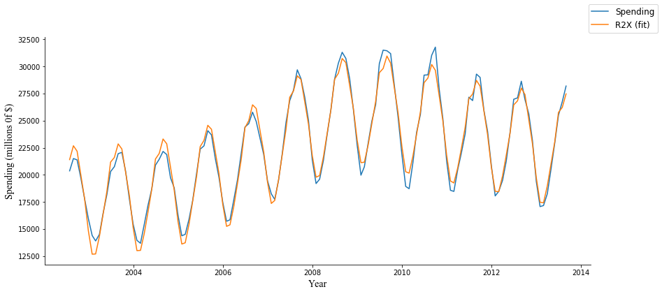

```python
dfPub['R2'] = dfPub['R1'] - dfPub['C']
dfPub['R2ErrorX'] = abs(dfPub['R2']/dfPub['Public Construction'])
dfPub['R2X'] = dfPub['MovAvg'] + dfPub['C']
dfPub.drop(['sqErr'],axis=1,inplace=True)
print('Average Error: ', sum(dfPub['R2ErrorX'])/len(dfPub))
print(dfPub)
fig,ax = plt.subplots()
ax.plot(dfPub['Public Construction'],label='Spending')
ax.plot(dfPub['R2X'], label = 'R2X (fit)')
ax.set_xlabel('Year',fontsize='14',fontname='Times New Roman')
ax.set_ylabel('Spending (millions 0f $)',fontsize='14',fontname='Times New Roman')
ax.spines['right'].set_visible(False)
ax.spines['top'].set_visible(False)
fig.legend(fontsize=12)
fig.set_size_inches(14,6)
```

```
Correlation, lag  1     0.6322426709090311
Correlation, lag  2     0.3064995963745286
Correlation, lag  3     0.016615917743238257
Correlation, lag  4     -0.3749951464284437
Correlation, lag  5     -0.5745066686993782
Correlation, lag  6     -0.6360252052924398
Correlation, lag  7     -0.6425642279739693
Correlation, lag  8     -0.40902612933630556
Correlation, lag  9     -0.05927403050425125
Correlation, lag  10     0.13885056695292233
Correlation, lag  11     0.4610539680769145
Correlation, lag  12     0.6199043732843016
Correlation, lag  13     0.4898496230237448
Correlation, lag  14     0.46821963390190974
Correlation, lag  15     0.16226212150488747
Correlation, lag  16     -0.12461342222875987
Correlation, lag  17     -0.29533827350419456
Correlation, lag  18     -0.47611265244748263
Correlation, lag  19     -0.5253972732806438
Correlation, lag  20     -0.37192666568812655
Correlation, lag  21     -0.20807880214824367
Correlation, lag  22     0.013465984415997632
Correlation, lag  23     0.35518834005052063
Correlation, lag  24     0.3507528638196484
period =  1      Maximum Correlation =  0.6322426709090311
```

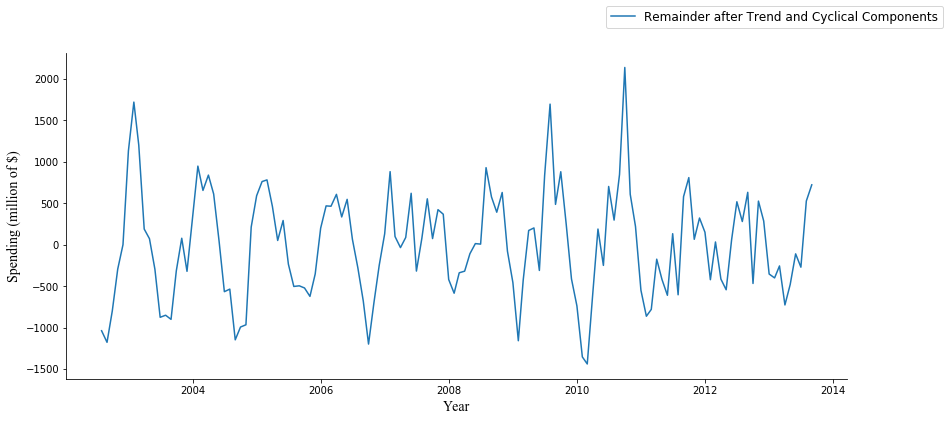

```python
fig,ax = plt.subplots()
ax.plot(dfPub['R2'],label='Remainder after Trend and Cyclical Components')
ax.set_xlabel('Year',fontsize='14',fontname='Times New Roman')
ax.set_ylabel('Spending (million of $)',fontsize='14',fontname='Times New Roman')
ax.spines['right'].set_visible(False)
ax.spines['top'].set_visible(False)
fig.legend(fontsize=12)
fig.set_size_inches(14,6)
maxCorr = 0.0
period = np.NaN
for i in range(1,25):
    corr = dfPub['R2'].autocorr(lag=i)
    print('Correlation, lag ',i,'   ',corr)
    if corr > maxCorr:
        maxCorr = corr
        period = i
print('period = ',period,'     Maximum Correlation = ',maxCorr)
```

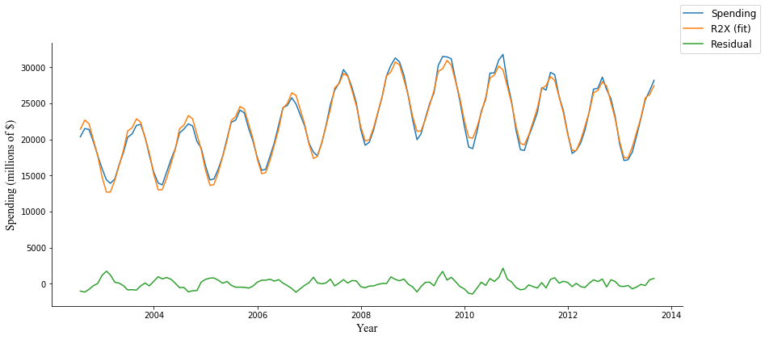

```python
fig,ax = plt.subplots()
ax.plot(dfPub['Public Construction'],label='Spending')
ax.plot(dfPub['R2X'],label='R2X (fit)')
ax.plot(dfPub['R2'],label='Residual')
ax.set_xlabel('Year',fontsize='14',fontname='Times New Roman')
ax.set_ylabel('Spending (millions of $)',fontsize='14',fontname='Times New Roman')
ax.spines['right'].set_visible(False)
ax.spines['top'].set_visible(False)
fig.legend(fontsize=12)

fig.set_size_inches(14,6)
```

```python
for a in [0.1 * i for i in range(1,20)]:
    dfPub['aC'] = a*dfPub['C']
    dfPub['R3'] = dfPub['R1'] - dfPub['aC']
    dfPub['sqErr'] = dfPub['R3']**2
    print('Squared Error for a =','{:.1f}'.format(a),':',sum(dfPub['sqErr']))
```

```
Squared Error for a = 0.1 : 1426494372.8684332
Squared Error for a = 0.2 : 1138628289.8563435
Squared Error for a = 0.3 : 884628804.8456756
Squared Error for a = 0.4 : 664495917.8364309
Squared Error for a = 0.5 : 478229628.8286083
Squared Error for a = 0.6 : 325829937.8222076
Squared Error for a = 0.7 : 207296844.81722978
Squared Error for a = 0.8 : 122630349.81367418
Squared Error for a = 0.9 : 71830452.81154072
Squared Error for a = 1.0 : 54897153.81082963
Squared Error for a = 1.1 : 71830452.81154083
Squared Error for a = 1.2 : 122630349.81367444
Squared Error for a = 1.3 : 207296844.81723017
Squared Error for a = 1.4 : 325829937.8222086
Squared Error for a = 1.5 : 478229628.82860845
Squared Error for a = 1.6 : 664495917.8364316
Squared Error for a = 1.7 : 884628804.8456765
Squared Error for a = 1.8 : 1138628289.8563442
Squared Error for a = 1.9 : 1426494372.8684344
```